# Credit Default Risk Scorecard

Predictive Risk Modeling Framework Using the R Tidymodel Package

Author

Patrick Lefler

Published

November 25, 2025

**Note**

Tidymodels is a comprehensive ecosystem of R packages designed to streamline the machine learning and statistical modeling workflow using “tidy” data principles. By providing a unified and consistent syntax, it allows users to easily switch between different underlying computational engines—such as random forests or linear regression—without needing to learn unique code for each algorithm. The framework covers the entire modeling pipeline, offering specialized tools for essential tasks including data splitting, preprocessing, model tuning, and performance evaluation.

# Executive Summary

This analysis develops a comprehensive credit default risk scorecard using machine learning techniques. The scorecard provides:

- **Predictive Models**: Logistic regression and random forest algorithms
- **Risk Segmentation**: Customer stratification into risk tiers
- **Portfolio Analytics**: Monte Carlo simulation for expected losses
- **Decision Tools**: Interactive visualizations for risk assessment

# 1. Data Overview

## 1.1 Data Quality Assessment

**Display Code**

```r
# Summary statistics
train_summary <- train_data %>%
  summarise(
    `Total Observations` = comma(n()),
    `Default Rate` = percent(mean(default == "Yes"), accuracy = 0.01),
    `Avg Loan Amount` = dollar(mean(loan_amount)),
    `Avg Income` = dollar(mean(income)),
    `Avg DTI` = percent(mean(debt_to_income), accuracy = 0.1),
    `Missing Values` = as.character(sum(is.na(.)))
  ) %>%
  pivot_longer(everything(), names_to = "Metric", values_to = "Value")

kable(train_summary,
      caption = "Dataset Summary Statistics",
      format = "html") %>%
  kable_styling(bootstrap_options = c("striped", "hover"))
```

Dataset Summary Statistics

| Metric | Value |
| --- | --- |
| Total Observations | 3,500 |
| Default Rate | 39.09% |
| Avg Loan Amount | $23,030,993 |
| Avg Income | $250,000 |
| Avg DTI | 34.9% |
| Missing Values | 0 |

## 1.2 Target Variable Distribution

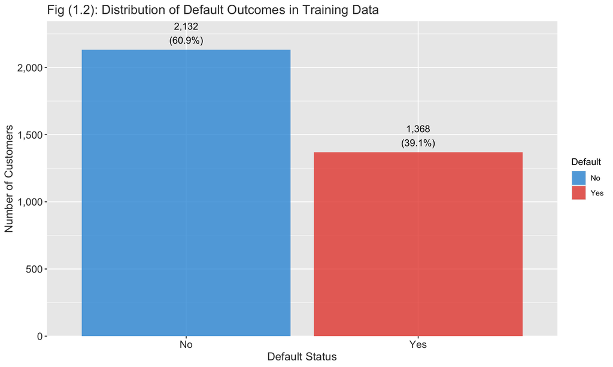

# 2. Exploratory Data Analysis

## 2.1 Feature Distributions by Default Status

**Display Code**

[figure not shown]

```r
# Select key numeric features
key_features <- train_data %>%
  select(
    default,
    income,
    debt_to_income,
    credit_utilization,
    num_delinquencies,
    loan_amount,
    interest_rate
  ) %>%
  pivot_longer(-default, names_to = "feature", values_to = "value")

p <- ggplot(key_features, aes(x = value, y = feature, fill = default)) +
  geom_density_ridges(alpha = 0.7, scale = 1.5) +
  scale_fill_manual(values = risk_colors) +
  facet_wrap(~feature, scales = "free", ncol = 2) +
  labs(
    title = "Fig (2.1): Feature Distributions by Default Status",
    x = "Value",
    y = "Feature",
    fill = "Default"
  ) +
  theme(strip.text = element_text(face = "bold")) +
  theme_gray() +
  themeMain

p
```

## 2.2 Risk Factor Correlation Matrix

**Display Code**

```r
####| fig-cap: "Correlation heatmap of numeric predictors"

# Compute correlation matrix
cor_data <- train_data %>%
  select(where(is.numeric), -customer_id) %>%
  cor(use = "complete.obs")

# Convert to long format
cor_long <- cor_data %>%
  as.data.frame() %>%
  rownames_to_column("var1") %>%
  pivot_longer(-var1, names_to = "var2", values_to = "correlation")

cor_long[cor_long == 1] <- NA

plot_2.2 <- ggplot(cor_long, aes(x = var1, y = var2, fill = correlation)) +
  geom_tile() +
  scale_fill_gradient2(
    low = "#3498db",
    mid = "#DCDCDC",
    high = "#e74c3c",
    midpoint = 0,
    limits = c(-.04, .04)
  ) +
  labs(
    title = "Fig (2.2): Feature Correlation Matrix",
    x = NULL,
    y = NULL,
    fill = "Correlation"
  )  +
  theme_gray() +
  themePlotly +
  theme(
  axis.text.x = element_text(angle = 45, hjust = 1),
  panel.grid = element_blank()
  )

ggplotly(plot_2.2)
```

[interactive chart not shown]

## 2.3 Default Rates by Categorical Features

**Display Code**

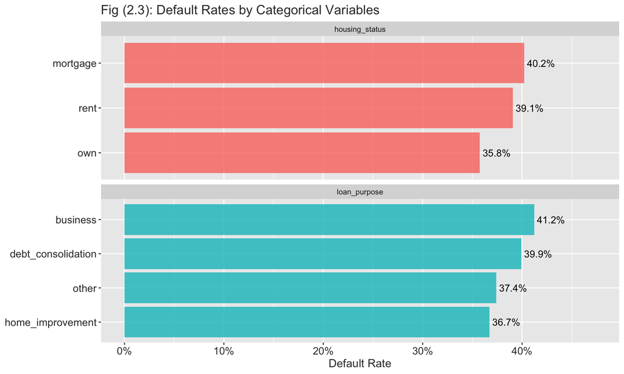

```r
categorical_default <- train_data %>%
  select(default, loan_purpose, housing_status) %>%
  pivot_longer(-default, names_to = "category", values_to = "value") %>%
  group_by(category, value, default) %>%
  summarise(n = n(), .groups = "drop") %>%
  group_by(category, value) %>%
  mutate(
    total = sum(n),
    percentage = n / total
  ) %>%
  filter(default == "Yes")

p <- ggplot(categorical_default, aes(x = reorder(value, percentage), y = percentage, fill = category)) +
  geom_col(alpha = 0.8, show.legend = FALSE) +
  geom_text(aes(label = percent(percentage, accuracy = 0.1)), hjust = -0.1, size = 4) +
  scale_y_continuous(labels = percent, limits = c(0, max(categorical_default$percentage) * 1.15)) +
  coord_flip() +
  facet_wrap(~category, scales = "free_y", ncol = 1) +
  labs(
    title = "Fig (2.3): Default Rates by Categorical Variables",
    x = NULL,
    y = "Default Rate"
  ) +
  theme(strip.text = element_text(face = "bold")) +
  theme_gray() +
  themeMain

p
```

# 3. Model Development

## 3.1 Feature Engineering & Recipe

**Display Code**

```r
# Create modeling recipe
credit_recipe <- recipe(default ~ ., data = train_data) %>%
  # Remove ID variable
  step_rm(customer_id) %>%
  # Remove zero-variance predictors
  step_zv(all_predictors()) %>%
  # One-hot encode categorical variables
  step_dummy(all_nominal_predictors()) %>%
  # Normalize numeric predictors
  step_normalize(all_numeric_predictors()) %>%
  # Handle class imbalance with SMOTE
  step_smote(default, over_ratio = 0.8)

# Prep to see processed features
credit_recipe_prepped <- prep(credit_recipe)

cat("Recipe successfully created with",
    length(credit_recipe_prepped$term_info$variable),
    "features after preprocessing\n")
```

```
Recipe successfully created with 17 features after preprocessing
```

## 3.2 Model Specifications

**Display Code**

```r
# Logistic Regression
logistic_spec <- logistic_reg(penalty = tune(), mixture = 1) %>%
  set_engine("glmnet") %>%
  set_mode("classification")

# Random Forest
rf_spec <- rand_forest(
  mtry = tune(),
  trees = 500,
  min_n = tune()
) %>%
  set_engine("ranger", importance = "impurity") %>%
  set_mode("classification")

# Create workflows
logistic_wf <- workflow() %>%
  add_recipe(credit_recipe) %>%
  add_model(logistic_spec)

rf_wf <- workflow() %>%
  add_recipe(credit_recipe) %>%
  add_model(rf_spec)
```

## 3.3 Cross-Validation Setup

**Display Code**

```r
set.seed(456)
cv_folds <- vfold_cv(train_data, v = 5, strata = default)

# Metrics
credit_metrics <- metric_set(roc_auc, accuracy, sensitivity, specificity)

cat("5-fold cross-validation with stratification\n")
```

```
5-fold cross-validation with stratification
```

## 3.4 Hyperparameter Tuning

**Display Code**

```r
# Logistic regression grid
logistic_grid <- grid_regular(
  penalty(range = c(-5, 0)),
  levels = 10
)

# Random forest grid
rf_grid <- grid_regular(
  mtry(range = c(3, 8)),
  min_n(range = c(5, 20)),
  levels = 5
)

# Tune logistic regression
set.seed(789)
logistic_tune <- tune_grid(
  logistic_wf,
  resamples = cv_folds,
  grid = logistic_grid,
  metrics = credit_metrics,
  control = control_grid(save_pred = TRUE, verbose = FALSE)
)

# Tune random forest
set.seed(789)
rf_tune <- tune_grid(
  rf_wf,
  resamples = cv_folds,
  grid = rf_grid,
  metrics = credit_metrics,
  control = control_grid(save_pred = TRUE, verbose = FALSE)
)

cat("Hyperparameter tuning complete\n")
```

```
Hyperparameter tuning complete
```

## 3.5 Model Performance Comparison

**Display Code**

```r
# Collect metrics
logistic_results <- logistic_tune %>%
  collect_metrics() %>%
  mutate(model = "Logistic Regression")

rf_results <- rf_tune %>%
  collect_metrics() %>%
  mutate(model = "Random Forest")

# Best models
best_logistic <- select_best(logistic_tune, metric = "roc_auc")
best_rf <- select_best(rf_tune, metric = "roc_auc")

# Combine and display top results
all_results <- bind_rows(logistic_results, rf_results) %>%
  filter(.metric == "roc_auc") %>%
  arrange(desc(mean)) %>%
  head(10)

kable(all_results %>% select(model, mean, std_err),
      digits = 4,
      col.names = c("Model", "ROC AUC", "Std Error"),
      caption = "Top 10 Model Configurations by ROC AUC") %>%
  kable_styling(bootstrap_options = c("striped", "hover"))
```

Top 10 Model Configurations by ROC AUC

| Model | ROC AUC | Std Error |
| --- | --- | --- |
| Logistic Regression | 0.7239 | 0.0102 |
| Logistic Regression | 0.7231 | 0.0104 |
| Logistic Regression | 0.7226 | 0.0104 |
| Logistic Regression | 0.7226 | 0.0104 |
| Logistic Regression | 0.7226 | 0.0104 |
| Logistic Regression | 0.7226 | 0.0104 |
| Logistic Regression | 0.7224 | 0.0106 |
| Random Forest | 0.7102 | 0.0082 |
| Random Forest | 0.7099 | 0.0100 |
| Random Forest | 0.7088 | 0.0095 |

**Display Code**

```r
####| fig-cap: "Hyperparameter tuning results"

plot_3.5 <- bind_rows(logistic_results, rf_results) %>%
  filter(.metric == "roc_auc") %>%
  ggplot(aes(x = model, y = mean, fill = model)) +
  geom_boxplot(alpha = 0.7) +
  geom_jitter(width = 0.2, alpha = 0.3) +
  scale_fill_brewer(palette = "Set2") +
  labs(
    title = "Fig (3.5): Model Performance Comparison (Cross-Validation)",
    x = "Model",
    y = "ROC AUC",
    fill = "Model"
  ) +
  theme(legend.position = "none")

ggplotly(plot_3.5)
```

[interactive chart not shown]

# 4. Final Model Training & Evaluation

## 4.1 Train Final Models

**Display Code**

```r
# Finalize workflows
final_logistic_wf <- finalize_workflow(logistic_wf, best_logistic)
final_rf_wf <- finalize_workflow(rf_wf, best_rf)

# Fit on full training set
final_logistic_fit <- fit(final_logistic_wf, train_data)
final_rf_fit <- fit(final_rf_wf, train_data)

cat("Final models trained on full training set\n")
```

```
Final models trained on full training set
```

## 4.2 Test Set Performance

**Display Code**

```r
# Generate predictions
logistic_pred <- augment(final_logistic_fit, test_data) %>%
  mutate(default = factor(default, levels = c("No", "Yes")))

rf_pred <- augment(final_rf_fit, test_data) %>%
  mutate(default = factor(default, levels = c("No", "Yes")))

# Calculate metrics using explicit classification metric set
logistic_metrics <- bind_rows(
  logistic_pred %>% accuracy(truth = default, estimate = .pred_class),
  logistic_pred %>% roc_auc(truth = default, .pred_Yes),
  logistic_pred %>% sensitivity(truth = default, estimate = .pred_class),
  logistic_pred %>% specificity(truth = default, estimate = .pred_class),
  logistic_pred %>% precision(truth = default, estimate = .pred_class),
  logistic_pred %>% recall(truth = default, estimate = .pred_class)
) %>%
  mutate(model = "Logistic Regression")

rf_metrics <- bind_rows(
  rf_pred %>% accuracy(truth = default, estimate = .pred_class),
  rf_pred %>% roc_auc(truth = default, .pred_Yes),
  rf_pred %>% sensitivity(truth = default, estimate = .pred_class),
  rf_pred %>% specificity(truth = default, estimate = .pred_class),
  rf_pred %>% precision(truth = default, estimate = .pred_class),
  rf_pred %>% recall(truth = default, estimate = .pred_class)
) %>%
  mutate(model = "Random Forest")

# Combine results
test_results <- bind_rows(logistic_metrics, rf_metrics) %>%
  select(model, .metric, .estimate) %>%
  pivot_wider(names_from = .metric, values_from = .estimate)

kable(test_results,
      digits = 4,
      caption = "Test Set Performance Metrics") %>%
  kable_styling(bootstrap_options = c("striped", "hover"))
```

Test Set Performance Metrics

| model | accuracy | roc_auc | sensitivity | specificity | precision | recall |
| --- | --- | --- | --- | --- | --- | --- |
| Logistic Regression | 0.6940 | 0.2707 | 0.7708 | 0.5658 | 0.7477 | 0.7708 |
| Random Forest | 0.6767 | 0.3040 | 0.7836 | 0.4982 | 0.7227 | 0.7836 |

## 4.3 ROC Curves

**Display Code**

```r
# Calculate ROC curves
logistic_roc <- logistic_pred %>%
  roc_curve(truth = default, .pred_Yes) %>%
  mutate(model = "Logistic Regression")

rf_roc <- rf_pred %>%
  roc_curve(truth = default, .pred_Yes) %>%
  mutate(model = "Random Forest")

roc_data <- bind_rows(logistic_roc, rf_roc)

# Calculate AUC for annotation
logistic_auc <- logistic_pred %>%
  roc_auc(truth = default, .pred_Yes) %>%
  pull(.estimate)

rf_auc <- rf_pred %>%
  roc_auc(truth = default, .pred_Yes) %>%
  pull(.estimate)

plot_4.3 <- ggplot(roc_data, aes(x = 1 - specificity, y = sensitivity, color = model)) +
  geom_line(size = 1.2) +
  geom_abline(linetype = "dashed", color = "gray50") +
  annotate("text", x = 0.7, y = 0.3,
           label = paste0("Logistic AUC: ", round(logistic_auc, 3)),
           color = "#F8766D", size = 4) +
  annotate("text", x = 0.7, y = 0.2,
           label = paste0("RF AUC: ", round(rf_auc, 3)),
           color = "#00BFC4", size = 4) +
  scale_color_brewer(palette = "Set1") +
  labs(
    title = "Fig (4.3): ROC Curve Comparison",
    x = "False Positive Rate (1 - Specificity)",
    y = "True Positive Rate (Sensitivity)",
    color = "Model"
  ) +
  coord_equal()

ggplotly(plot_4.3)
```

[interactive chart not shown]

## 4.4 Calibration Plot

**Display Code**

```r
# Create calibration data
calibration_data <- bind_rows(
  logistic_pred %>%
    mutate(model = "Logistic Regression"),
  rf_pred %>%
    mutate(model = "Random Forest")
) %>%
  mutate(
    pred_bin = cut(.pred_Yes,
                   breaks = seq(0, 1, 0.1),
                   include.lowest = TRUE)
  ) %>%
  group_by(model, pred_bin) %>%
  summarise(
    predicted = mean(.pred_Yes),
    observed = mean(default == "Yes"),
    n = n(),
    .groups = "drop"
  )

plot_4.4 <- ggplot(calibration_data, aes(x = predicted, y = observed, color = model)) +
  geom_point(aes(size = n), alpha = 0.6) +
  geom_line() +
  geom_abline(linetype = "dashed", color = "gray50") +
  scale_color_brewer(palette = "Set1") +
  scale_size_continuous(range = c(2, 10)) +
  labs(
    title = "Fig (4.4): Calibration Plot",
    x = "Predicted Default Probability",
    y = "Observed Default Rate",
    color = "Model",
    size = "N"
  ) +
  coord_equal(xlim = c(0, 1), ylim = c(0, 1))

ggplotly(plot_4.4)
```

[interactive chart not shown]

## 4.5 Confusion Matrices

**Display Code**

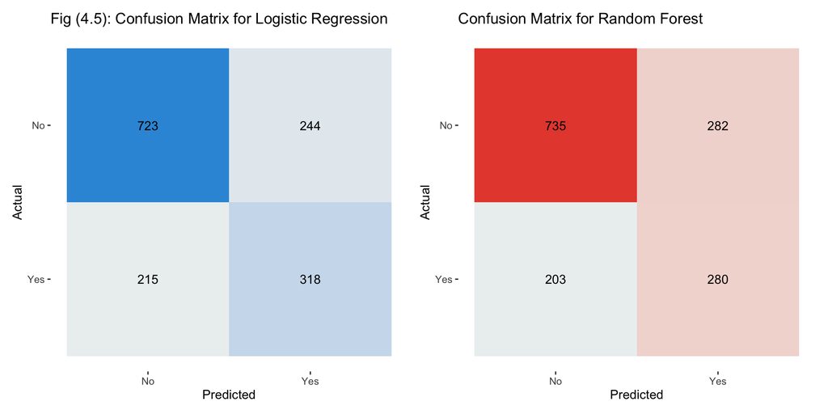

```r
# Logistic confusion matrix
logistic_cm <- logistic_pred %>%
  conf_mat(truth = default, estimate = .pred_class) %>%
  autoplot(type = "heatmap") +
  scale_fill_gradient(low = "#ecf0f1", high = "#3498db") +
  labs(
    title = "Fig (4.5): Confusion Matrix for Logistic Regression",
    x = "Predicted",
    y = "Actual"
  )

# Random forest confusion matrix
rf_cm <- rf_pred %>%
  conf_mat(truth = default, estimate = .pred_class) %>%
  autoplot(type = "heatmap") +
  scale_fill_gradient(low = "#ecf0f1", high = "#e74c3c") +
  labs(
    title = "Confusion Matrix for Random Forest",
    x = "Predicted",
    y = "Actual"
  )

logistic_cm + rf_cm
```

# 5. Feature Importance & Interpretation

## 5.1 Variable Importance

**Display Code**

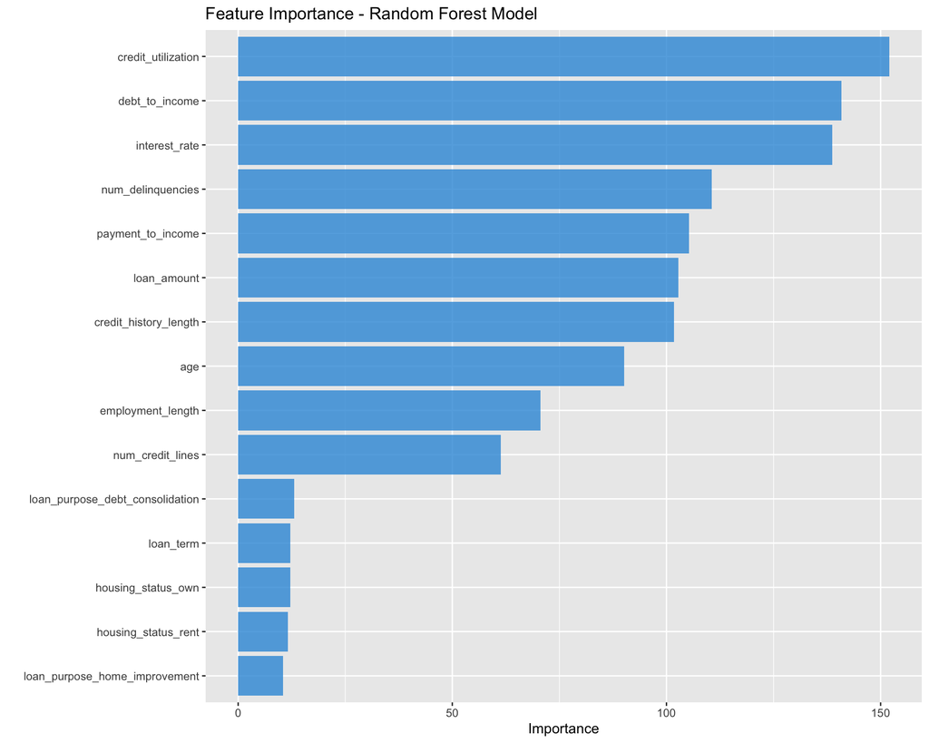

```r
# Extract and plot variable importance
rf_importance <- final_rf_fit %>%
  extract_fit_parsnip() %>%
  vip(num_features = 15, aesthetics = list(fill = "#3498db", alpha = 0.8)) +
  labs(title = "Feature Importance - Random Forest Model")

print(rf_importance)
```

## 5.2 Partial Dependence Plots

**Display Code**

[figure not shown]

```r
###| fig-cap: "Partial dependence plots showing relationship between key features and default probability"
#| message: false

library(pdp)

# Create custom prediction function
pred_wrapper <- function(object, newdata) {
  predict(object, newdata, type = "prob")$.pred_Yes
}

# Key features for PDP
key_vars <- c("debt_to_income", "credit_utilization", "income", "num_delinquencies")

# Generate partial dependence plots
pdp_list <- map(key_vars, ~{
  partial(final_rf_fit,
          pred.var = .x,
          pred.fun = pred_wrapper,
          train = train_data,
          plot = FALSE) %>%
    as_tibble() %>%
    mutate(variable = .x)
})

pdp_data <- bind_rows(pdp_list)

plot_5.2 <- ggplot(pdp_data, aes(x = get(names(pdp_data)[1]), y = yhat)) +
  geom_line(color = "#e74c3c", size = 1.2) +
  geom_smooth(se = TRUE, alpha = 0.2, color = "#3498db") +
  facet_wrap(~variable, scales = "free_x", ncol = 2) +
  labs(
    title = "Fig (5.2): Partial Dependence Plots",
    subtitle = "Impact of individual features on default probability",
    x = "Feature Value",
    y = "Predicted Default Probability"
  ) +
  theme(strip.text = element_text(face = "bold")) +
theme_gray() +
  themeMain

plot_5.2
```

# 6. Risk Scorecard Development

## 6.1 Score Generation

**Display Code**

```r
# Add predictions to full dataset
scored_data <- full_data %>%
  bind_cols(
    predict(final_rf_fit, full_data, type = "prob")
  ) %>%
  mutate(
    # Create risk score (0-1000)
    risk_score = round(.pred_Yes * 1000, 0),

    # Categorize into risk tiers
    risk_tier = case_when(
      risk_score < 200 ~ "Low Risk",
      risk_score < 400 ~ "Medium-Low Risk",
      risk_score < 600 ~ "Medium Risk",
      risk_score < 800 ~ "Medium-High Risk",
      TRUE ~ "High Risk"
    ),
    risk_tier = factor(risk_tier, levels = c(
      "Low Risk", "Medium-Low Risk", "Medium Risk",
      "Medium-High Risk", "High Risk"
    ))
  )

# Summary by risk tier
risk_summary <- scored_data %>%
  group_by(risk_tier) %>%
  summarise(
    count = n(),
    default_rate = mean(default == "Yes"),
    avg_score = mean(risk_score),
    avg_loan = mean(loan_amount),
    total_exposure = sum(loan_amount),
    .groups = "drop"
  ) %>%
  mutate(
    portfolio_pct = count / sum(count),
    exposure_pct = total_exposure / sum(total_exposure)
  )

kable(risk_summary %>%
        select(risk_tier, count, default_rate, avg_score, total_exposure, portfolio_pct),
      digits = c(0, 0, 4, 0, 0, 4),
      col.names = c("Risk Tier", "Count", "Default Rate", "Avg Score",
                    "Total Exposure", "Portfolio %"),
      caption = "Risk Tier Summary Statistics") %>%
  kable_styling(bootstrap_options = c("striped", "hover")) %>%
  row_spec(which(risk_summary$default_rate > 0.3), background = "#fadbd8")
```

Risk Tier Summary Statistics

| Risk Tier | Count | Default Rate | Avg Score | Total Exposure | Portfolio % |
| --- | --- | --- | --- | --- | --- |
| Low Risk | 719 | 0.0250 | 148 | 16881523462 | 0.1438 |
| Medium-Low Risk | 1880 | 0.0846 | 297 | 42927303889 | 0.3760 |
| Medium Risk | 1236 | 0.5324 | 498 | 29453951196 | 0.2472 |
| Medium-High Risk | 1039 | 0.9346 | 686 | 24256558268 | 0.2078 |
| High Risk | 126 | 0.9841 | 831 | 2663233726 | 0.0252 |

## 6.2 Risk Score Distribution

**Display Code**

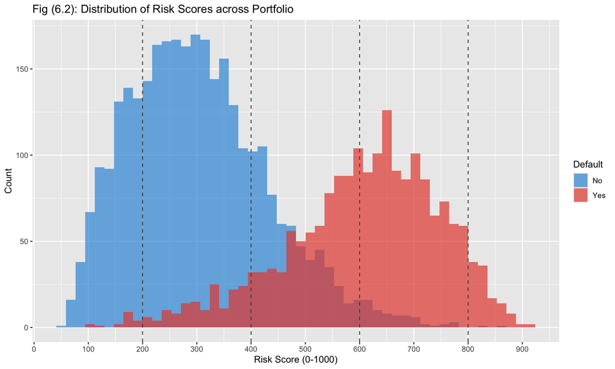

```r
plot_6.2 <- ggplot(scored_data, aes(x = risk_score, fill = default)) +
  geom_histogram(bins = 50, alpha = 0.7, position = "identity") +
  geom_vline(xintercept = c(200, 400, 600, 800),
             linetype = "dashed", color = "gray30") +
  scale_fill_manual(values = risk_colors) +
  scale_x_continuous(breaks = seq(0, 1000, 100)) +
  labs(
    title = "Fig (6.2): Distribution of Risk Scores across Portfolio",
    x = "Risk Score (0-1000)",
    y = "Count",
    fill = "Default"
  )

plot_6.2
```

## 6.3 Risk Tier Performance

**Display Code**

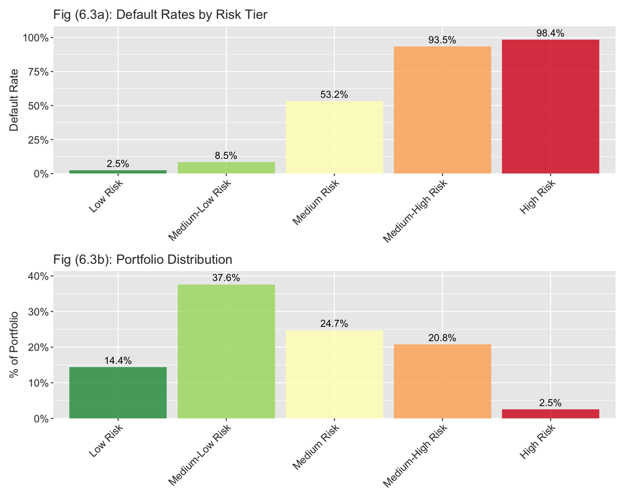

```r
####| fig-cap: "Risk tier analysis showing default rates and portfolio composition"

# Default rates by tier
plot_6.3_1 <- ggplot(risk_summary, aes(x = risk_tier, y = default_rate, fill = risk_tier)) +
  geom_col(alpha = 0.8) +
  geom_text(aes(label = percent(default_rate, accuracy = 0.1)),
            vjust = -0.5, size = 4) +
  scale_fill_brewer(palette = "RdYlGn", direction = -1) +
  scale_y_continuous(labels = percent, expand = expansion(mult = c(0, 0.1))) +
  labs(
    title = "Fig (6.3a): Default Rates by Risk Tier",
    x = NULL,
    y = "Default Rate"
  ) +
  themeMain +
  theme(
    axis.text.x = element_text(angle = 45, hjust = 1),
    legend.position = "none"
  )

# Portfolio composition
plot_6.3_2 <- ggplot(risk_summary, aes(x = risk_tier, y = portfolio_pct, fill = risk_tier)) +
  geom_col(alpha = 0.8) +
  geom_text(aes(label = percent(portfolio_pct, accuracy = 0.1)),
            vjust = -0.5, size = 4) +
  scale_fill_brewer(palette = "RdYlGn", direction = -1) +
  scale_y_continuous(labels = percent, expand = expansion(mult = c(0, 0.1))) +
  labs(
    title = "Fig (6.3b): Portfolio Distribution",
    x = NULL,
    y = "% of Portfolio"
  ) +
  themeMain +
  theme(
    axis.text.x = element_text(angle = 45, hjust = 1),
    legend.position = "none"
  )

plot_6.3_1 / plot_6.3_2
```

# 7. Portfolio Risk Analytics

## 7.1 Loss Given Default Assumptions

**Display Code**

```r
# Define loss parameters
lgd_assumptions <- tibble(
  risk_tier = c("Low Risk", "Medium-Low Risk", "Medium Risk",
                "Medium-High Risk", "High Risk"),
  lgd_rate = c(0.30, 0.40, 0.50, 0.60, 0.70),
  recovery_rate = 1 - lgd_rate
)

kable(lgd_assumptions,
      digits = 2,
      col.names = c("Risk Tier", "Loss Given Default", "Recovery Rate"),
      caption = "Loss Given Default Assumptions by Risk Tier") %>%
  kable_styling(bootstrap_options = c("striped", "hover"))
```

Loss Given Default Assumptions by Risk Tier

| Risk Tier | Loss Given Default | Recovery Rate |
| --- | --- | --- |
| Low Risk | 0.3 | 0.7 |
| Medium-Low Risk | 0.4 | 0.6 |
| Medium Risk | 0.5 | 0.5 |
| Medium-High Risk | 0.6 | 0.4 |
| High Risk | 0.7 | 0.3 |

## 7.2 Expected Loss Calculation

**Display Code**

```r
# Calculate expected loss
portfolio_risk <- scored_data %>%
  left_join(lgd_assumptions, by = "risk_tier") %>%
  mutate(
    pd = .pred_Yes,  # Probability of default
    ead = loan_amount,  # Exposure at default
    expected_loss = pd * lgd_rate * ead
  )

# Portfolio-level metrics
portfolio_metrics <- portfolio_risk %>%
  summarise(
    total_exposure = sum(ead),
    total_expected_loss = sum(expected_loss),
    avg_pd = mean(pd),
    loss_rate = total_expected_loss / total_exposure
  )

# By risk tier
risk_tier_el <- portfolio_risk %>%
  group_by(risk_tier) %>%
  summarise(
    count = n(),
    total_exposure = sum(ead),
    total_expected_loss = sum(expected_loss),
    avg_pd = mean(pd),
    loss_rate = total_expected_loss / total_exposure,
    .groups = "drop"
  )

kable(risk_tier_el,
      digits = c(0, 0, 0, 0, 4, 4),
      col.names = c("Risk Tier", "Count", "Total Exposure",
                    "Expected Loss", "Avg PD", "Loss Rate"),
      caption = "Expected Loss by Risk Tier") %>%
  kable_styling(bootstrap_options = c("striped", "hover"))
```

Expected Loss by Risk Tier

| Risk Tier | Count | Total Exposure | Expected Loss | Avg PD | Loss Rate |
| --- | --- | --- | --- | --- | --- |
| High Risk | 126 | 2663233726 | 1551078030 | 0.8314 | 0.5824 |
| Low Risk | 719 | 16881523462 | 772334034 | 0.1482 | 0.0458 |
| Medium Risk | 1236 | 29453951196 | 7300758568 | 0.4975 | 0.2479 |
| Medium-High Risk | 1039 | 24256558268 | 9990213842 | 0.6865 | 0.4119 |
| Medium-Low Risk | 1880 | 42927303889 | 5100428620 | 0.2971 | 0.1188 |

## 7.3 Expected Loss Visualization

**Display Code**

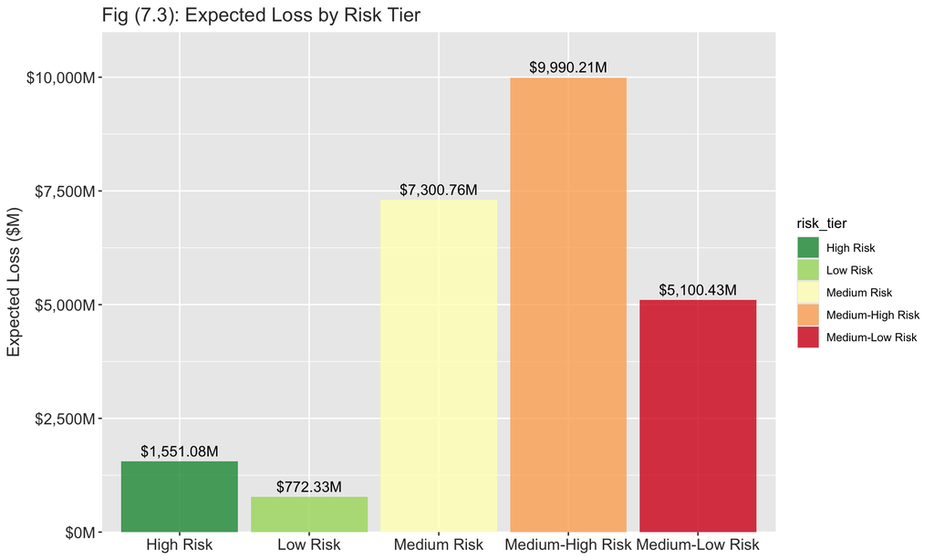

```r
p <- ggplot(risk_tier_el, aes(x = risk_tier, y = total_expected_loss,
                               fill = risk_tier)) +
  geom_col(alpha = 0.8) +
  geom_text(aes(label = dollar(total_expected_loss, scale = 1e-6, suffix = "M")),
            vjust = -0.5, size = 4) +
  scale_fill_brewer(palette = "RdYlGn", direction = -1) +
  scale_y_continuous(labels = dollar_format(scale = 1e-6, suffix = "M"),
                    expand = expansion(mult = c(0, 0.1))) +
  labs(
    title = "Fig (7.3): Expected Loss by Risk Tier",
    x = NULL,
    y = "Expected Loss ($M)"
  ) +
  theme(
    axis.text.x = element_text(angle = 45, hjust = 1),
    legend.position = "none"
  ) +
  theme_gray() +
  themeMain

p
```

## 7.4 Monte Carlo Simulation

**Display Code**

```r
## #| fig-cap: "Monte Carlo simulation of portfolio losses"

set.seed(714)
n_simulations <- 50000

# Run simulations
simulate_portfolio_loss <- function(portfolio_data, lgd_data) {
  portfolio_data %>%
    left_join(lgd_data, by = "risk_tier") %>%
    mutate(
      default_sim = rbinom(n(), 1, .pred_Yes),
      loss = default_sim * lgd_rate * loan_amount
    ) %>%
    summarise(total_loss = sum(loss)) %>%
    pull(total_loss)
}

# Generate simulation results
sim_results <- map_dbl(1:n_simulations, ~{
  simulate_portfolio_loss(scored_data, lgd_assumptions)
})

# Calculate VaR and ES
var_95 <- quantile(sim_results, 0.95)
var_99 <- quantile(sim_results, 0.99)
var_999 <- quantile(sim_results, 0.999)
expected_shortfall_95 <- mean(sim_results[sim_results >= var_95])
expected_loss <- mean(sim_results)

# Create simulation summary
sim_summary <- tibble(
  metric = c("Mean Loss", "Std Dev", "95% Value at Risk", "99% Value at Risk", "99.9% Value at Risk", "95% Expected Shortfall"),
  value = c(
    expected_loss,
    sd(sim_results),
    var_95,
    var_99,
    var_999,
    expected_shortfall_95
  )
) %>%
  mutate(value_formatted = dollar(value, scale = 1e-6, suffix = "M"))

kable(sim_summary %>% select(metric, value_formatted),
      col.names = c("Metric", "Value"),
      caption = "Monte Carlo Simulation Results (50,000 iterations)") %>%
  kable_styling(bootstrap_options = c("striped", "hover"))
```

Monte Carlo Simulation Results (50,000 iterations)

| Metric | Value |
| --- | --- |
| Mean Loss | $24,716.13M |
| Std Dev | $455.39M |
| 95% Value at Risk | $25,461.00M |
| 99% Value at Risk | $25,771.37M |
| 99.9% Value at Risk | $26,155.03M |
| 95% Expected Shortfall | $25,653.00M |

**Display Code**

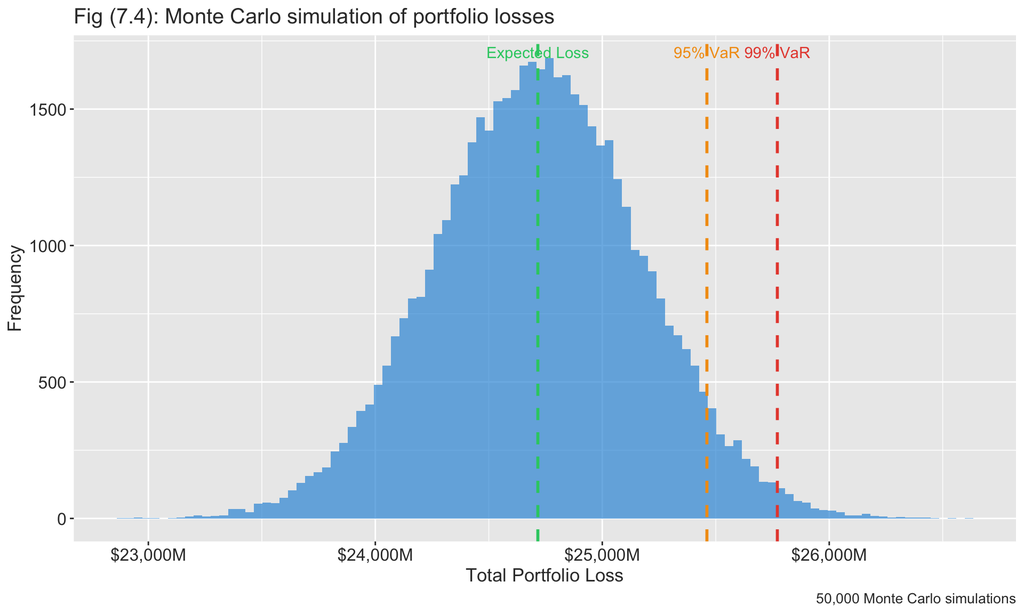

```r
# Plot distribution
sim_df <- tibble(loss = sim_results)

plot_7.4 <- ggplot(sim_df, aes(x = loss)) +
  geom_histogram(bins = 100, fill = "#3498db", alpha = 0.7) +
  geom_vline(xintercept = expected_loss,
             color = "#2ecc71", linetype = "dashed", size = 1) +
  geom_vline(xintercept = var_95,
             color = "#f39c12", linetype = "dashed", size = 1) +
  geom_vline(xintercept = var_99,
             color = "#e74c3c", linetype = "dashed", size = 1) +
  annotate("text", x = expected_loss, y = Inf,
           label = "Expected Loss", vjust = 2, color = "#2ecc71") +
  annotate("text", x = var_95, y = Inf,
           label = "95% VaR", vjust = 2, color = "#f39c12") +
  annotate("text", x = var_99, y = Inf,
           label = "99% VaR", vjust = 2, color = "#e74c3c") +
  scale_x_continuous(labels = dollar_format(scale = 1e-6, suffix = "M")) +
  labs(
    title = "Fig (7.4): Monte Carlo simulation of portfolio losses",
    caption = "50,000 Monte Carlo simulations",
    x = "Total Portfolio Loss",
    y = "Frequency"
  ) +
  theme_gray() +
  themeMain

plot_7.4
```

# 8. Business Recommendations

## 8.1 Risk Management Strategy

Based on the analysis, we recommend the following risk-based strategies:

**Display Code**

```r
recommendations <- tribble(
  ~`Risk Tier`, ~`Action`, ~`Rationale`,
  "Low Risk", "Approve with standard terms", "Default rate <5%, strong creditworthiness",
  "Medium-Low Risk", "Approve with monitoring", "Acceptable risk, periodic review recommended",
  "Medium Risk", "Conditional approval", "Enhanced documentation and monitoring required",
  "Medium-High Risk", "Risk-based pricing", "Higher rates to compensate for elevated risk",
  "High Risk", "Decline or secured lending", "Default rate >30%, requires collateral"
)

kable(recommendations,
      caption = "Recommended Actions by Risk Tier") %>%
  kable_styling(bootstrap_options = c("striped", "hover")) %>%
  column_spec(1, bold = TRUE) %>%
  row_spec(5, background = "#fadbd8")
```

Recommended Actions by Risk Tier

| Risk Tier | Action | Rationale |
| --- | --- | --- |
| Low Risk | Approve with standard terms | Default rate <5%, strong creditworthiness |
| Medium-Low Risk | Approve with monitoring | Acceptable risk, periodic review recommended |
| Medium Risk | Conditional approval | Enhanced documentation and monitoring required |
| Medium-High Risk | Risk-based pricing | Higher rates to compensate for elevated risk |
| High Risk | Decline or secured lending | Default rate >30%, requires collateral |

## 8.2 Capital Requirements

**Display Code**

```r
# Calculate regulatory capital (simplified Basel approach)
capital_requirements <- risk_tier_el %>%
  mutate(
    risk_weight = case_when(
      risk_tier == "Low Risk" ~ 0.20,
      risk_tier == "Medium-Low Risk" ~ 0.50,
      risk_tier == "Medium Risk" ~ 0.75,
      risk_tier == "Medium-High Risk" ~ 1.00,
      risk_tier == "High Risk" ~ 1.50
    ),
    rwa = total_exposure * risk_weight,
    capital_requirement = rwa * 0.08  # 8% capital ratio
  )

total_capital <- sum(capital_requirements$capital_requirement)

kable(capital_requirements %>%
        select(risk_tier, total_exposure, risk_weight, rwa, capital_requirement),
      digits = c(0, 0, 2, 0, 0),
      col.names = c("Risk Tier", "Exposure", "Risk Weight", "RWA", "Capital Required"),
      caption = paste0("Capital Requirements (Total: ",
                      dollar(total_capital, scale = 1e-6, suffix = "M"), ")")) %>%
  kable_styling(bootstrap_options = c("striped", "hover"))
```

Capital Requirements (Total: $6,014.55M)

| Risk Tier | Exposure | Risk Weight | RWA | Capital Required |
| --- | --- | --- | --- | --- |
| High Risk | 2663233726 | 1.50 | 3994850589 | 319588047 |
| Low Risk | 16881523462 | 0.20 | 3376304692 | 270104375 |
| Medium Risk | 29453951196 | 0.75 | 22090463397 | 1767237072 |
| Medium-High Risk | 24256558268 | 1.00 | 24256558268 | 1940524661 |
| Medium-Low Risk | 42927303889 | 0.50 | 21463651945 | 1717092156 |

## 8.3 Portfolio Optimization Scenarios

**Display Code**

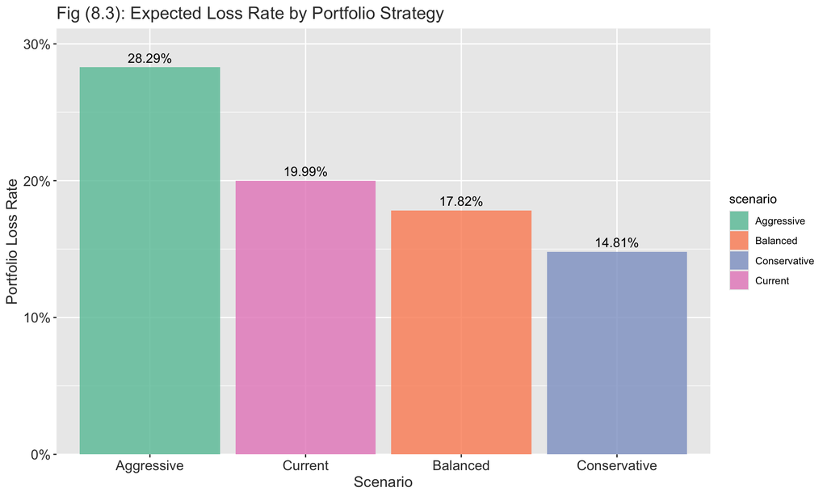

```r
###| fig-cap: "Impact of portfolio composition changes on expected loss"

# Create scenarios
scenarios <- tibble(
  scenario = c("Current", "Conservative", "Aggressive", "Balanced"),
  low_pct = c(0.25, 0.40, 0.15, 0.30),
  med_low_pct = c(0.30, 0.30, 0.20, 0.30),
  med_pct = c(0.25, 0.20, 0.25, 0.25),
  med_high_pct = c(0.15, 0.08, 0.25, 0.12),
  high_pct = c(0.05, 0.02, 0.15, 0.03)
) %>%
  pivot_longer(-scenario, names_to = "tier", values_to = "percentage") %>%
  mutate(
    tier = str_remove(tier, "_pct"),
    tier = str_replace_all(tier, "_", "-"),
    tier = str_to_title(tier),
    tier = case_when(
      tier == "Low" ~ "Low Risk",
      tier == "Med-Low" ~ "Medium-Low Risk",
      tier == "Med" ~ "Medium Risk",
      tier == "Med-High" ~ "Medium-High Risk",
      tier == "High" ~ "High Risk"
    )
  ) %>%
  left_join(
    risk_tier_el %>% select(risk_tier, avg_pd, loss_rate),
    by = c("tier" = "risk_tier")
  ) %>%
  group_by(scenario) %>%
  summarise(
    weighted_pd = sum(percentage * avg_pd),
    weighted_loss_rate = sum(percentage * loss_rate),
    .groups = "drop"
  )

plot_8.3 <- ggplot(scenarios, aes(x = reorder(scenario, -weighted_loss_rate),
                           y = weighted_loss_rate, fill = scenario)) +
  geom_col(alpha = 0.8) +
  geom_text(aes(label = percent(weighted_loss_rate, accuracy = 0.01)),
            vjust = -0.5, size = 4) +
  scale_fill_brewer(palette = "Set2") +
  scale_y_continuous(labels = percent, expand = expansion(mult = c(0, 0.1))) +
  labs(
    title = "Fig (8.3): Expected Loss Rate by Portfolio Strategy",
    x = "Scenario",
    y = "Portfolio Loss Rate"
  ) +
  theme(legend.position = "none") +
  theme_gray() +
  themeMain

plot_8.3
```

# 9. Conclusions & Next Steps

## Technical Implementation

This scorecard can be operationalized through: - API deployment for real-time scoring - Batch scoring for existing portfolio monitoring - Integration with loan origination systems - Automated reporting dashboards

# Appendix: Technical Details

## Model Specifications

**Random Forest** - Engine: ranger - Trees: 500 - mtry: 3 - min_n: 20